# Data550FinalProject1

Jiamin Zhao

2025-10-01

#Introduction

The Diabetes Health Indicators Dataset is a cleaned version of the 2015 CDC BRFSS survey, available on Kaggle (https://www.kaggle.com/datasets/alexteboul/diabetes-health-indicators-dataset ). It contains over 250k survey responses and 22 variables spanning demographics (Age, Sex, Education, Income), health behaviors (Smoker, PhysActivity, Diet, Alcohol use), and chronic conditions (HighBP, HighChol, Stroke, HeartDiseaseorAttack). The outcome Diabetes_012 has three classes (0 = no diabetes/gestational only; 1 = prediabetes; 2 = diabetes).

Objectives. (1) Provide descriptive summaries across diabetes status. (2) Show diabetes prevalence across age groups (Figure 1). (3) Fit a logistic regression model for diabetes risk.

#Data: load & basic cleaning

Converts the raw CSV into an analysis-ready data frame and assigns readable labels so later summaries/plots/models work consistently.

```r
# Read CSV (put file at ./data/ or the project root)
data_file <- if (file.exists("data/diabetes_012_health_indicators_BRFSS2015.csv")) {
  "data/diabetes_012_health_indicators_BRFSS2015.csv"
} else {
  "diabetes_012_health_indicators_BRFSS2015.csv"
}

stopifnot(file.exists(data_file))  # stop if file missing

dat <- read_csv(data_file, show_col_types = FALSE)

# ---- Make key variables readable (idempotent) ----
# Diabetes_012 is numeric 0/1/2 in the CSV; convert to labeled factor
if (!is.factor(dat$Diabetes_012)) {
  dat$Diabetes_012 <- factor(dat$Diabetes_012,
                             levels = c(0,1,2),
                             labels = c("No/gestational only","Prediabetes","Diabetes"))
}

# Binary indicators as factors
if (!is.factor(dat$PhysActivity)) dat$PhysActivity <- factor(dat$PhysActivity, levels = c(0,1), labels = c("No","Yes"))
if (!is.factor(dat$HighBP))       dat$HighBP       <- factor(dat$HighBP,       levels = c(0,1), labels = c("No","Yes"))

# Age groups from BRFSS codes 1..13 → readable labels
age_labs <- c("18–24","25–29","30–34","35–39","40–44","45–49",
              "50–54","55–59","60–64","65–69","70–74","75–79","80+")
dat$AgeGrp <- factor(dat$Age, levels = 1:13, labels = age_labs)
```

#Table 1 — Education × Income × Diabetes

```r
# Create a three-way cross-tabulation (Education × Income × Diabetes),
# showing counts and within-diabetes-group percentages.
tbl_ei <- dat %>%
  count(Diabetes_012, Education, Income, name = "Count") %>%
  group_by(Diabetes_012) %>%
  mutate(Percent_in_group = round(100 * Count / sum(Count), 1)) %>%
  ungroup()

kable(tbl_ei, caption = "Table 1. Education × Income × Diabetes (counts and % within Diabetes group)")
```

Table 1. Education × Income × Diabetes (counts and % within Diabetes group)

| Diabetes_012 | Education | Income | Count | Percent_in_group |
| --- | --- | --- | --- | --- |
| No/gestational only | 1 | 1 | 22 | 0.0 |
| No/gestational only | 1 | 2 | 15 | 0.0 |
| No/gestational only | 1 | 3 | 19 | 0.0 |
| No/gestational only | 1 | 4 | 13 | 0.0 |
| No/gestational only | 1 | 5 | 19 | 0.0 |
| No/gestational only | 1 | 6 | 15 | 0.0 |
| No/gestational only | 1 | 7 | 12 | 0.0 |
| No/gestational only | 1 | 8 | 10 | 0.0 |
| No/gestational only | 2 | 1 | 532 | 0.2 |
| No/gestational only | 2 | 2 | 444 | 0.2 |
| No/gestational only | 2 | 3 | 503 | 0.2 |
| No/gestational only | 2 | 4 | 434 | 0.2 |
| No/gestational only | 2 | 5 | 335 | 0.2 |
| No/gestational only | 2 | 6 | 223 | 0.1 |
| No/gestational only | 2 | 7 | 113 | 0.1 |
| No/gestational only | 2 | 8 | 115 | 0.1 |
| No/gestational only | 3 | 1 | 1062 | 0.5 |
| No/gestational only | 3 | 2 | 968 | 0.5 |
| No/gestational only | 3 | 3 | 1207 | 0.6 |
| No/gestational only | 3 | 4 | 1034 | 0.5 |
| No/gestational only | 3 | 5 | 961 | 0.4 |
| No/gestational only | 3 | 6 | 717 | 0.3 |
| No/gestational only | 3 | 7 | 470 | 0.2 |
| No/gestational only | 3 | 8 | 449 | 0.2 |
| No/gestational only | 4 | 1 | 2585 | 1.2 |
| No/gestational only | 4 | 2 | 3293 | 1.5 |
| No/gestational only | 4 | 3 | 4815 | 2.3 |
| No/gestational only | 4 | 4 | 6133 | 2.9 |
| No/gestational only | 4 | 5 | 7199 | 3.4 |
| No/gestational only | 4 | 6 | 8924 | 4.2 |

[output cut: 108 more lines]

Table 1 shows how education and income strata distribute within each diabetes category. Diabetes groups tend to concentrate in lower education/income bands compared with the no-diabetes group, suggesting socioeconomic gradients.

#Figure 1 — Diabetes prevalence by age group

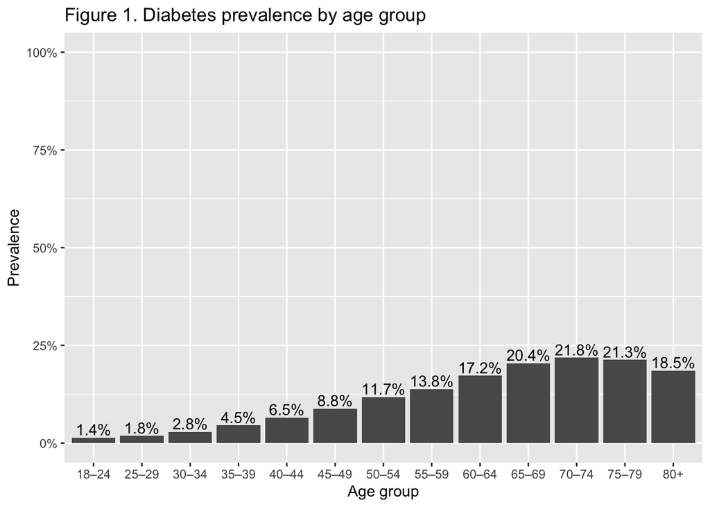

```r
# Compute diabetes prevalence per age group and visualize
prev_age <- dat %>%
  filter(!is.na(AgeGrp)) %>%
  mutate(diabetes_binary = as.integer(Diabetes_012 == "Diabetes")) %>%
  group_by(AgeGrp) %>%
  summarise(prevalence = mean(diabetes_binary, na.rm = TRUE), .groups = "drop")

# Quick sanity check (should be 0..1, not all NA)
# print(summary(prev_age))

ggplot(prev_age, aes(x = AgeGrp, y = prevalence)) +
  geom_col() +
  geom_text(aes(label = scales::percent(prevalence, accuracy = 0.1)), vjust = -0.25) +
  scale_y_continuous(limits = c(0, 1), labels = scales::percent) +
  labs(title = "Figure 1. Diabetes prevalence by age group",
       x = "Age group", y = "Prevalence")
```

Figure 1 shows diabetes prevalence rising with age, peaking in older groups, indicating a strong age gradient.

#Logistic regression — Diabetes ~ Age + BMI + PhysActivity + HighBP

```r
# Binary outcome: Diabetes vs (No/gestational only + Prediabetes)
dat$diabetes_bin <- as.integer(dat$Diabetes_012 == "Diabetes")  # 1 = Diabetes, 0 = otherwise

fit <- glm(diabetes_bin ~ Age + BMI + PhysActivity + HighBP,
           data = dat, family = binomial())

coefs <- summary(fit)$coefficients
OR    <- exp(coefs[, "Estimate"])
SE    <- coefs[, "Std. Error"]
lower <- exp(coefs[, "Estimate"] - 1.96*SE)
upper <- exp(coefs[, "Estimate"] + 1.96*SE)

out <- data.frame(
  Variable = rownames(coefs),
  OR       = round(OR, 3),
  CI_lower = round(lower, 3),
  CI_upper = round(upper, 3),
  p_value  = signif(coefs[, "Pr(>|z|)"], 3),
  row.names = NULL
)

kable(out, caption = "Logistic regression: Odds ratios for Diabetes (vs No/Prediabetes)")
```

Logistic regression: Odds ratios for Diabetes (vs No/Prediabetes)

| Variable | OR | CI_lower | CI_upper | p_value |
| --- | --- | --- | --- | --- |
| (Intercept) | 0.003 | 0.003 | 0.003 | 0 |
| Age | 1.173 | 1.167 | 1.178 | 0 |
| BMI | 1.075 | 1.073 | 1.077 | 0 |
| PhysActivityYes | 0.693 | 0.675 | 0.711 | 0 |
| HighBPYes | 3.160 | 3.075 | 3.249 | 0 |

Higher Age and BMI are associated with higher odds of diabetes. Reporting PhysActivity = “Yes” is associated with lower odds, while HighBP = “Yes” is associated with higher odds. Estimates are odds ratios with 95% CIs.